# Програмный RAID

Майоров Дмитрий Андреевич

# Информация

## Докладчик

- Майоров Дмитрий Андреевич

# Цель работы

Освоить работу с RAID-массивами при помощи утилиты mdadm.

# Выполнение лабораторной работы

Добавляем к нашей виртуальной машине к контроллеру SATA три диска размером 512 MiB

[figure not shown]

Рисунок 1

# Выполнение лабораторной работы

Проверяем наличие созданных нами на предыдущем этапе дисков

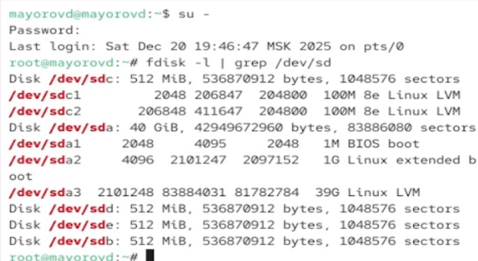

Рисунок 2

# Выполнение лабораторной работы

Создаем на каждом из дисков раздел

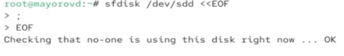

Рисунок 3

# Выполнение лабораторной работы

Проверяем текущий тип созданных разделов. Каждый раздел имеет тип 83(Linux)

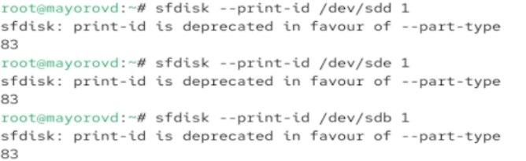

Рисунок 4

# Выполнение лабораторной работы

Просмотриваем, какие типы партиций, относящиеся к RAID, можно задать

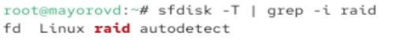

Рисунок 5

# Выполнение лабораторной работы

Установливаем тип разделов в Linux raid autodetect

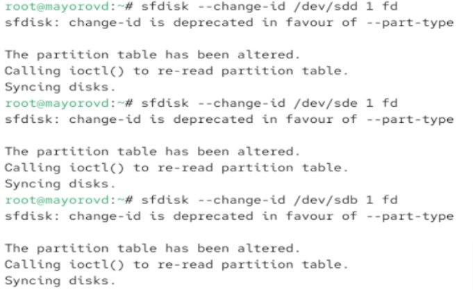

Рисунок 6

# Выполнение лабораторной работы

Просмотриваем состояние дисков

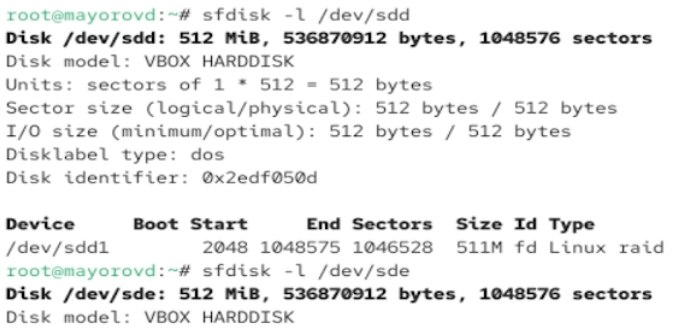

Рисунок 7

# Выполнение лабораторной работы

Устанавливаем mdadm

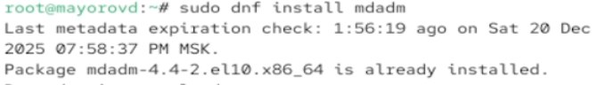

Рисунок 8

# Выполнение лабораторной работы

При помощи утилиты mdadm создаем массив RAID 1 из двух дисков

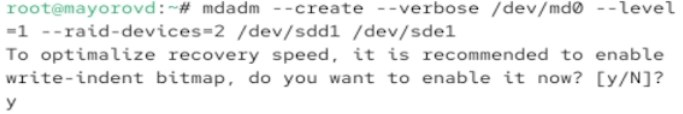

Рисунок 9

# Выполнение лабораторной работы

Проверяем состояние массива RAID

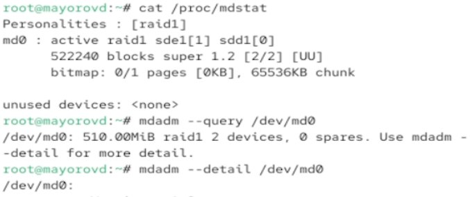

Рисунок 10

# Выполнение лабораторной работы

Создаем файловую систему на RAID

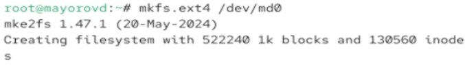

Рисунок 11

# Выполнение лабораторной работы

Подмонтировываем RAID

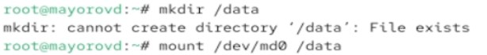

Рисунок 12

# Выполнение лабораторной работы

В /etc/fstab для автомонтирования добавляем запись

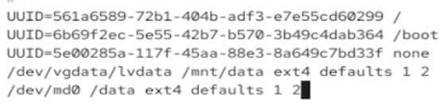

Рисунок 13

# Выполнение лабораторной работы

Имитируем сбой одного из дисков. Удаляем сбойный диск и заменяем диск в массиве

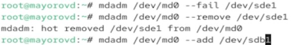

Рисунок 14

# Выполнение лабораторной работы

Удаляем массив и очищаем метаданные

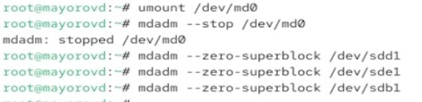

Рисунок 15

# Выполнение лабораторной работы

Создаем массив RAID 1 из двух дисков

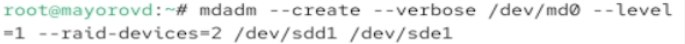

Рисунок 16

# Выполнение лабораторной работы

# Выполнение лабораторной работы

Подмонтировываем /dev/md0

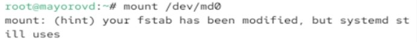

Рисунок 18

# Выполнение лабораторной работы

Проверяем состояние массива

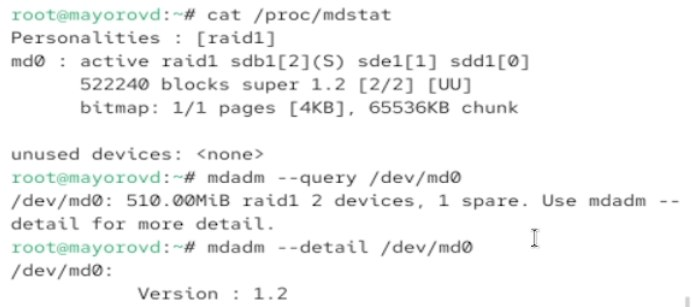

Рисунок 19

# Выполнение лабораторной работы

Имитируем сбой одного из дисков. Проверяем состояние массива

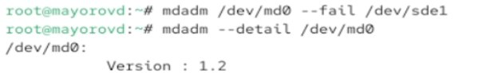

Рисунок 20

# Выполнение лабораторной работы

Удаляем массив и очищаем метаданные

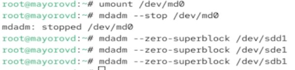

Рисунок 21

# Выполнение лабораторной работы

Создаем массив RAID 1 из двух дисков

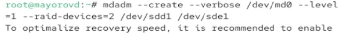

Рисунок 22

# Выполнение лабораторной работы

Добавляем третий диск

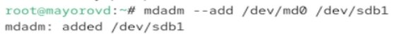

Рисунок 23

# Выполнение лабораторной работы

Подмонтировываем /dev/md0

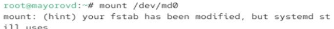

Рисунок 24

# Выполнение лабораторной работы

Проверяем состояние массива

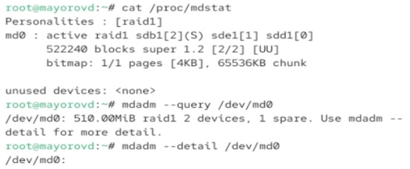

Рисунок 25

# Выполнение лабораторной работы

Изменяем тип массива RAID и проверяем состояние массива

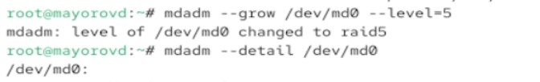

Рисунок 26

# Выполнение лабораторной работы

Изменяем количество дисков в массиве RAID 5

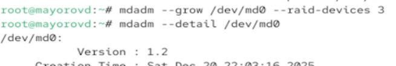

Рисунок 27

# Выполнение лабораторной работы

Удаляем массив и очищаем метаданные

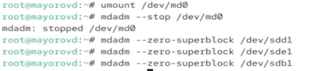

Рисунок 28

# Выполнение лабораторной работы

Комментируем запись в /etc/fstab

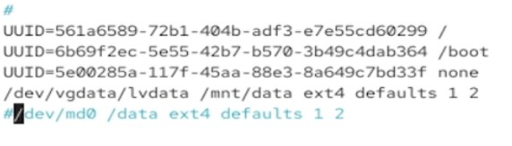

Рисунок 29

# Выводы

Мы освоили работу с RAID-массивами при помощи утилиты mdadm.